# Primer avance informe

Constanza González

14-11-2021

En Chile, desde el año 1965 la tasa de mortalidad materna ha ido disminuyendo considerablemente, por ejemplo, en esos años se presentaba una mortalidad materna de 299/100.000 nacidos vivos, siendo ésta una de las más altas de América. En esos años, el aborto y sus complicaciones eran una de las causas con mayor número de muertes maternas, abarcando casi un tercio del total de muertes.

En la actualidad, Chile es uno de los países con mejores condiciones de salud materno-infatil del mundo. Sin embargo, la tasa de mortalidad materna sigue teniendo un número alto de muertes, alcanzando aproximadamente 8 defunciones cada 1000 nacidos vivos. En todo el mundo, la muerte de la mujer durante el embarazo o parto sigue siendo un problema grave de salud pública. Muchos autores han estado investigando porqué, a nivel mundial, seguimos manteniendo una tasa relativamente alta.

La idea de este informe es informar sobre los porcentajes de mortalidad materna en Chile e intentar comprender a qué se podría deber el aumento o disminución de la muerte materna, si se nos está dando la educación sexual necesaria para evitar fallecer por alguna de las causas ya nombradas. Si bien los datos no están del todo actualizados nos permitirán responder a varias preguntas que nos servirán para comprender más adelante el porqué de los porcentajes tan altos en algunas causas, si es que existe alguna coincidencia entre ellas, entre otras.

Para poder lograr lo nombrado en el párrafo anterior, primero se mostrará la base de datos, dando un pequeño contexto desde donde la obtuvimos. Se utilizarán gráficos con cada una de las bases de datos para poder analizarlas y responder algunas preguntas para comprender mejor los resultados obtenidos. Para finalizar, se buscará dar información para que el lector pueda tener precaución y así pueda disminuir las posibilidades de obtener una muerte en el embarazo o parto.

Las bases de datos que se utilizarán incluyen los datos de las defunciones maternas ocurridas en Chile desde el año 2011 hasta el 2014 con sus respectivas causas y fueron obtenidas desde la página oficial del MINSAL (https://deis.minsal.cl/#estadisticas). Si observamos alguna de las bases de datos, podemos ver que se nombran todas las causas por las que se ha obtenido alguna muerte materna, históricamente hablando. Podemos observar que se cuantifican cada una de las causas de defunción, añadiendo a su lado la Razón de Mortalidad Materna por cien mil nacidos vivos corregidos, la base incluye también información de cuántas defunciones existen en ciertos rangos etarios.

Primero que todo, para saber qué tanto van variando las causas y qué tanto aumenta la tasa de Mortalidad Materna con el paso del tiempo, realizaremos un gráfico para cada año y, finalmente, uno con todos los años comparándolos entre sí para comenzar a observar si es que existe alguna razón por la que ciertas causas siempre tengan una cantidad alta de defunciones. Además, buscamos responder una pregunta que nos servirá en un futuro “¿Cuáles fueron las causas con mayor tasa de mortalidad en los años estudiados?”

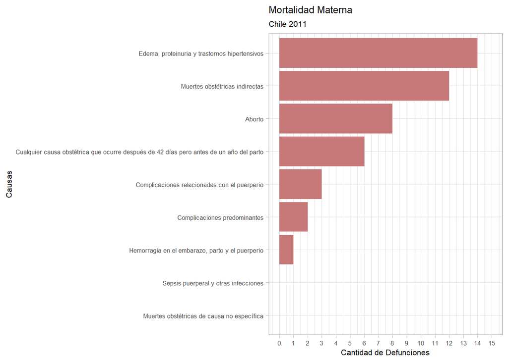

```r
datos_2011 %>%
  ggplot()+
  aes(x=reorder(Causas, Defunciones), weight = Defunciones) +
  geom_bar(fill = "#C77979") +
  scale_y_continuous(limits = c(0, 15), breaks = seq(0, 15, by =1))+
  labs(
    y = "Cantidad de Defunciones",
    x = "Causas",
    title = "Mortalidad Materna",
    subtitle = "Chile 2011"
  ) +
  coord_flip() +
  theme_light()+
  theme(text = element_text(size=8))
```

Es claro ver que en el año 2011 la causa con mayor número de defunciones es “Edema, proteinuria y trastornos hipertensivos”, seguida por “Muertes obstétricas indirectas” que no se diferencian por mucho más. Podemos observar también que, en el 2011, no hay registro de muertes por “Sepsis puerperal y otras infecciones” ni “Muertes obstétricas de causa no específica”.

Buscamos comparar con los otros años para ver si es que existe alguna relación o si “Edema, proteinuria y trastornos hipertensivos” sigue manteniéndose como la causa con mayor cantidad de defunsiones, por lo que ahora observaremos el gráfico 2.

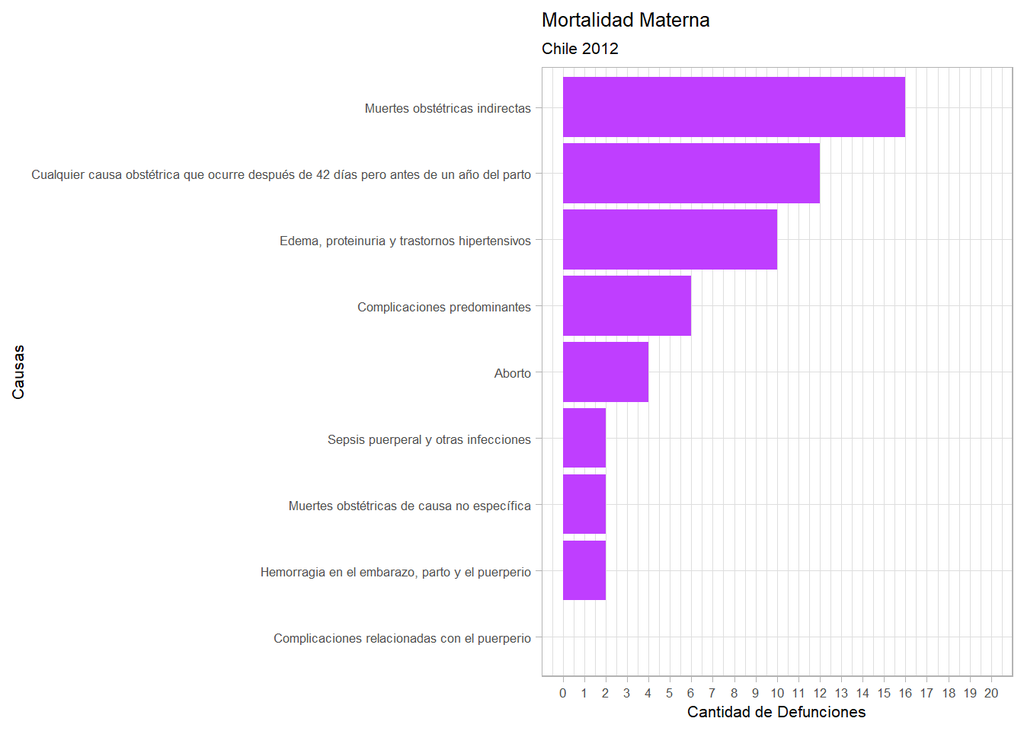

```r
ruta2 = file.choose()
datos_2012 = rio::import(ruta2) #base 2012

datos_2012 %>%
  ggplot()+
  aes(x=reorder(Causas, Defunciones), weight = Defunciones) +
  geom_bar(fill = "darkorchid1") +
  scale_y_continuous(limits = c(0, 20), breaks = seq(0, 20, by =1))+
  labs(
    y = "Cantidad de Defunciones",
    x = "Causas",
    title = "Mortalidad Materna",
    subtitle = "Chile 2012"
  ) +
  coord_flip() +
  theme_light()+
  theme(text = element_text(size=8))
```

Podemos ver que esta vez “Muertes obstétricas indirectas” es la que esta vez mantiene un mayor número de defunciones, seguida por “Cualquier causa obstétrica que ocurre después de 42 días pero antes de un año del parto”, siendo “Complicaciones relacionadas con el puerperio” la única causa de Mortalidad Materna que en este año no presenta registros de muertes.

Continuamos ahora con el gráfico del año 2013.

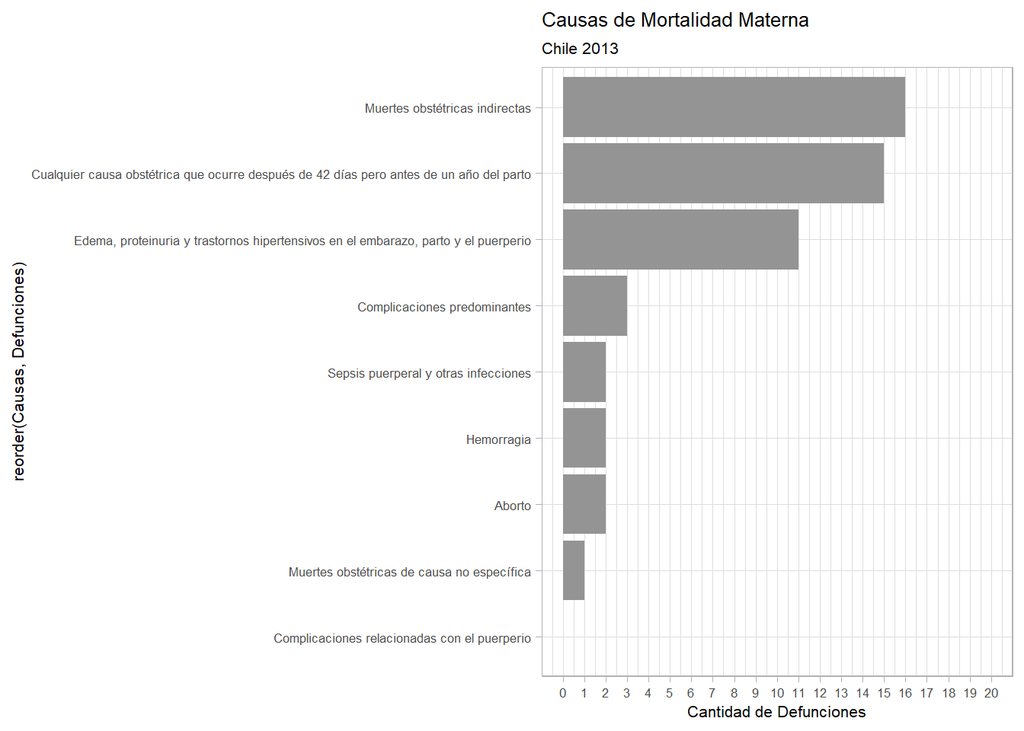

```r
ruta3 = file.choose()
datos_2013 = rio::import(ruta3) #base 2013

datos_2013 %>%
  ggplot()+
  aes(x=reorder(Causas, Defunciones), weight = Defunciones) +
  geom_bar(fill = "gray58") +
  scale_y_continuous(limits = c(0, 20), breaks = seq(0, 20, by =1))+
  labs(
    y = "Cantidad de Defunciones",
    title = "Causas de Mortalidad Materna",
    subtitle = "Chile 2013"
  ) +
  coord_flip() +
  theme_light()+
  theme(text = element_text(size=8))
```

En el 2013 “Muertes obstétricas indirectas” y “Cualquier causa obstétrica que ocurre después de 42 días, pero antes de un año de parto” también se mantienen encabezando la lista, claramente con valores distintos, pero continuan liderando, más adelante intentaremos averiguar si es que existe alguna otra coincidencia en el resto de los años o si existe alguna razón por la que se mantienen éstas en los primeros lugares de la lista. También observamos que “Complicaciones relacionadas con el puerperio” es la causa que en este año se mantiene sin registros de muerte materna.

Observaremos ahora un gráfico sobre los datos que tenemos sobre las defunciones maternas del año 2014, último año del que se mantiene registro.

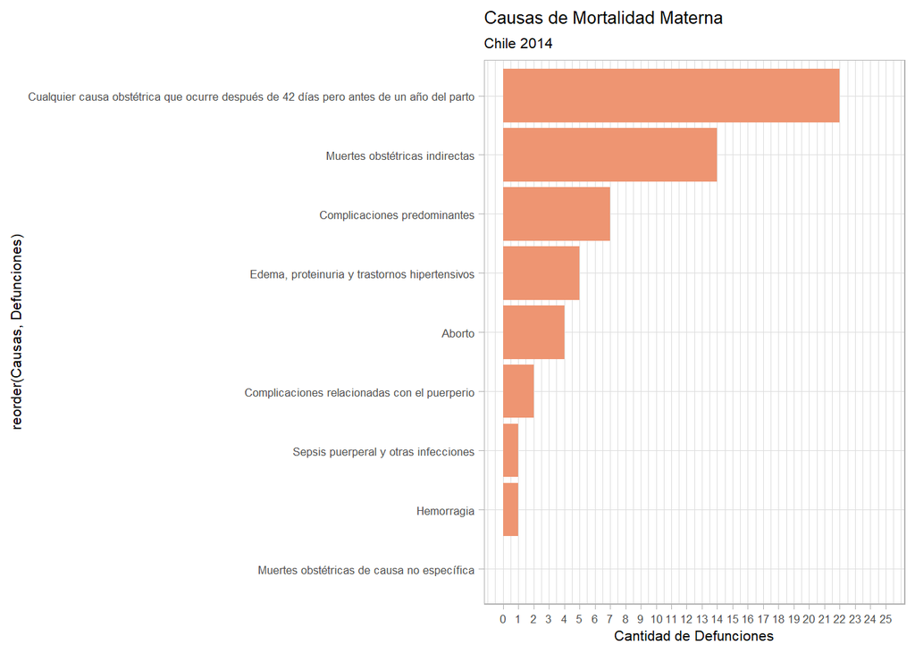

```r
ruta4 = file.choose()
datos_2014 = rio::import(ruta4) #base 2014

datos_2014 %>%
  ggplot()+
  aes(x=reorder(Causas, Defunciones), weight = Defunciones) +
  geom_bar(fill = "lightsalmon2") +
  scale_y_continuous(limits = c(0, 25), breaks = seq(0, 25, by =1))+
  labs(
    y = "Cantidad de Defunciones",
    title = "Causas de Mortalidad Materna",
    subtitle = "Chile 2014"
  ) +
  coord_flip() +
  theme_light()+
  theme(text = element_text(size=8))
```

Finalmente, en el año 2014 podemos observar que “Cualquier causa obstétrica que ocurre después de 42 días, pero antes de un año del parto” es la causa que mayor cantidad de defunciones presenta, seguida por “Muertes obstétricas indirectas”, que se ha mantenido en los primeros lugares en casi todos los años. Además, podemos ver que “Muertes obstétricas de causa no específica” no presenta datos de muertes en este año en específico.